# PSYC2020L Assignment 6

[name]

2025-09-26

## Goals for Review:

- Tidying data

For each question, please make sure you include code output. If the question asks for comparison or further explanation, please make sure to include that as well.

## Setting Up

### 1) Rename this assignment as “Lab 6 Assignment [Last, First].Rmd”

### 2) Check and set (if needed) your working directory. If you’d like to load packages with `library()`, please do so in this block. Make sure to load the `tidyverse` package!

```r
library(tidyverse)
here::here()
```

```
## [1] "C:/Users/jessi/OneDrive - Georgia Institute of Technology/Courses/GTA/PSYC 2020/PSYC 2020L Site"
```

## Import

### 3) The `tidyverse` package includes a dataset called `billboard` that has song rankings for the Billboard Top 100 songs from the year 2000. Use the `head()` function to display the first six rows. Then, use the `names()` to look at the column names.

```r
head(billboard)
```

```
## # A tibble: 6 × 79
##   artist      track date.entered   wk1   wk2   wk3   wk4   wk5   wk6   wk7   wk8
##   <chr>       <chr> <date>       <dbl> <dbl> <dbl> <dbl> <dbl> <dbl> <dbl> <dbl>
## 1 2 Pac       Baby… 2000-02-26      87    82    72    77    87    94    99    NA
## 2 2Ge+her     The … 2000-09-02      91    87    92    NA    NA    NA    NA    NA
## 3 3 Doors Do… Kryp… 2000-04-08      81    70    68    67    66    57    54    53
## 4 3 Doors Do… Loser 2000-10-21      76    76    72    69    67    65    55    59
## 5 504 Boyz    Wobb… 2000-04-15      57    34    25    17    17    31    36    49
## 6 98^0        Give… 2000-08-19      51    39    34    26    26    19     2     2
## # ℹ 68 more variables: wk9 <dbl>, wk10 <dbl>, wk11 <dbl>, wk12 <dbl>,
## #   wk13 <dbl>, wk14 <dbl>, wk15 <dbl>, wk16 <dbl>, wk17 <dbl>, wk18 <dbl>,
## #   wk19 <dbl>, wk20 <dbl>, wk21 <dbl>, wk22 <dbl>, wk23 <dbl>, wk24 <dbl>,
## #   wk25 <dbl>, wk26 <dbl>, wk27 <dbl>, wk28 <dbl>, wk29 <dbl>, wk30 <dbl>,
## #   wk31 <dbl>, wk32 <dbl>, wk33 <dbl>, wk34 <dbl>, wk35 <dbl>, wk36 <dbl>,
## #   wk37 <dbl>, wk38 <dbl>, wk39 <dbl>, wk40 <dbl>, wk41 <dbl>, wk42 <dbl>,
## #   wk43 <dbl>, wk44 <dbl>, wk45 <dbl>, wk46 <dbl>, wk47 <dbl>, wk48 <dbl>, …
```

```r
names(billboard)
```

```
##  [1] "artist"       "track"        "date.entered" "wk1"          "wk2"
##  [6] "wk3"          "wk4"          "wk5"          "wk6"          "wk7"
## [11] "wk8"          "wk9"          "wk10"         "wk11"         "wk12"
## [16] "wk13"         "wk14"         "wk15"         "wk16"         "wk17"
## [21] "wk18"         "wk19"         "wk20"         "wk21"         "wk22"
## [26] "wk23"         "wk24"         "wk25"         "wk26"         "wk27"
## [31] "wk28"         "wk29"         "wk30"         "wk31"         "wk32"
## [36] "wk33"         "wk34"         "wk35"         "wk36"         "wk37"
## [41] "wk38"         "wk39"         "wk40"         "wk41"         "wk42"
## [46] "wk43"         "wk44"         "wk45"         "wk46"         "wk47"
## [51] "wk48"         "wk49"         "wk50"         "wk51"         "wk52"
## [56] "wk53"         "wk54"         "wk55"         "wk56"         "wk57"
## [61] "wk58"         "wk59"         "wk60"         "wk61"         "wk62"
## [66] "wk63"         "wk64"         "wk65"         "wk66"         "wk67"
## [71] "wk68"         "wk69"         "wk70"         "wk71"         "wk72"
## [76] "wk73"         "wk74"         "wk75"         "wk76"
```

## Tidy

### 4a) Is the `billboards` dataset in wide or long format? How can you tell?

Wide! An “observation” here is a ranking in a given week, but all the weeks are in columns. They don’t have to specifically mention that an observation is a ranking in a week, but just something like this.

### 4b) Using the `?` tool on the dataset and / or the output from #3, please describe the contents of this dataset (specificially, an overview of what you can find in the columns) (1–2 sentences).

```r
#?billboards
```

In this dataset, we can find the artist name, track name, date that the track entered, and rankings for 76 weeks starting in 2000.

### 4c) Given what you said in #4a, would you want to use the `pivot_longer()` or `pivot_wider()` function on this data?

`pivot_longer()`

### 5) Using a pipe, let’s do a few things:

- Tidy the data as you planned to in #4c,
- Mutate the column with the numbered weeks so that it’s just numeric (hint: the `parse_number()` function will extract numbers from a string. Feel free to review its documentation with `?`),
- Assign this tidied version to a variable so we can continue using it.

After the pipe, print the first six rows from this tidied version.

```r
billboard_l <- billboard |>
  pivot_longer(cols = starts_with("wk"),
               names_to = "week", values_to = "ranking") |>
  mutate(week = parse_number(week))
head(billboard_l)
```

```
## # A tibble: 6 × 5
##   artist track                   date.entered  week ranking
##   <chr>  <chr>                   <date>       <dbl>   <dbl>
## 1 2 Pac  Baby Don't Cry (Keep... 2000-02-26       1      87
## 2 2 Pac  Baby Don't Cry (Keep... 2000-02-26       2      82
## 3 2 Pac  Baby Don't Cry (Keep... 2000-02-26       3      72
## 4 2 Pac  Baby Don't Cry (Keep... 2000-02-26       4      77
## 5 2 Pac  Baby Don't Cry (Keep... 2000-02-26       5      87
## 6 2 Pac  Baby Don't Cry (Keep... 2000-02-26       6      94
```

## Visualization

### 7a) Now, let’s plot some of this data. Let’s make a line graph that has time (week) on the x-axis and a song’s ranking on the y-axis. Start by using the `ggplot()` function to make a grid with axes (no geoms yet).

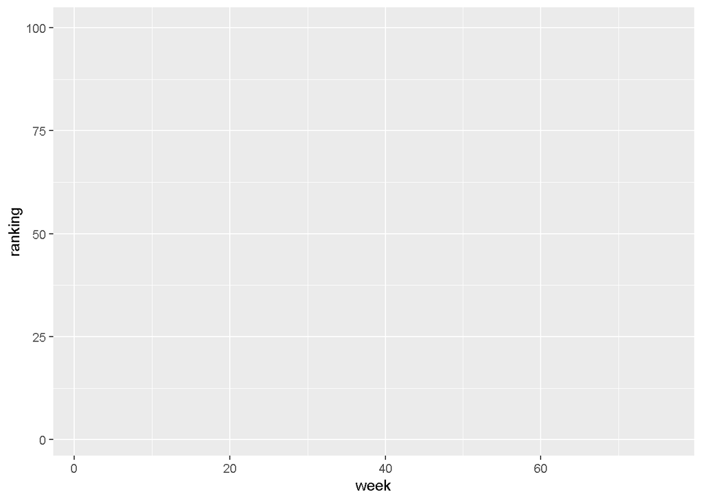

```r
billboard_l |>
  ggplot(aes(x = week, y = ranking))
```

### 7b) Now, let’s add a `geom_line()` to show the rankings of the different songs over time. Remember you will need to add a `group` argument to your aes.

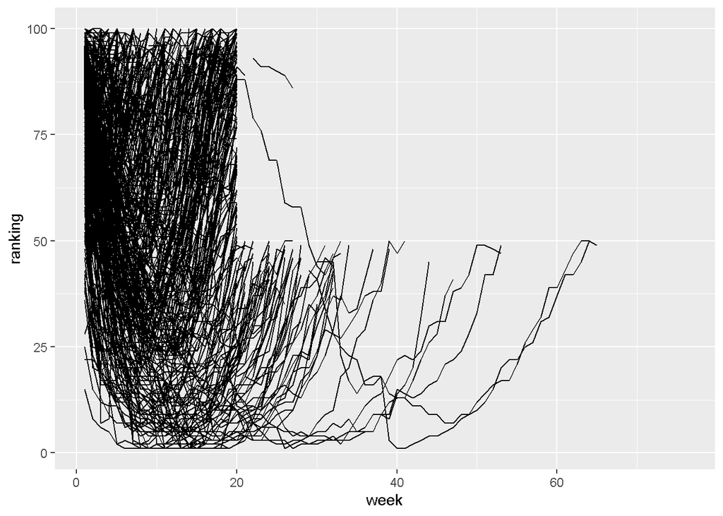

```r
billboard_l |>
  ggplot(aes(x = week, y = ranking, group = track)) +
  geom_line()
```

### 7c) Because higher is “worse” for rankings, let’s reverse the y-axis so higher on the y is “better” by adding a scale layer. The function `scale_y_reverse()` will do this for us!

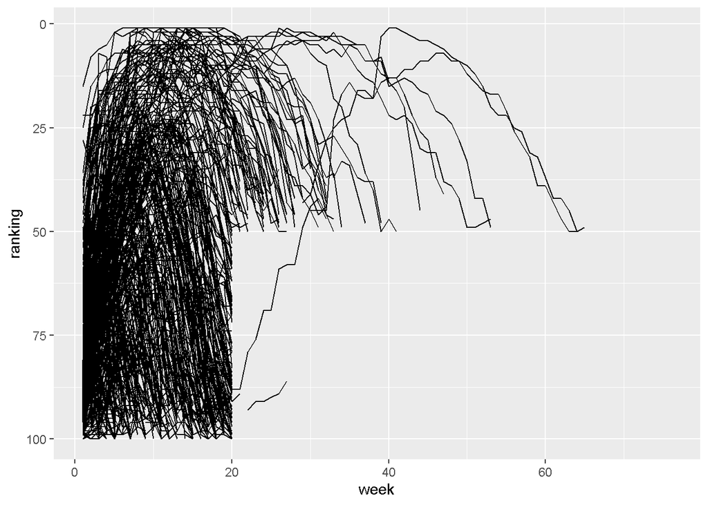

```r
billboard_l |>
  ggplot(aes(x = week, y = ranking, group = track)) +
  geom_line() +
  scale_y_reverse()
```

### 7d) Modify the `alpha` argument within your geom to make it easier to see the patterns.

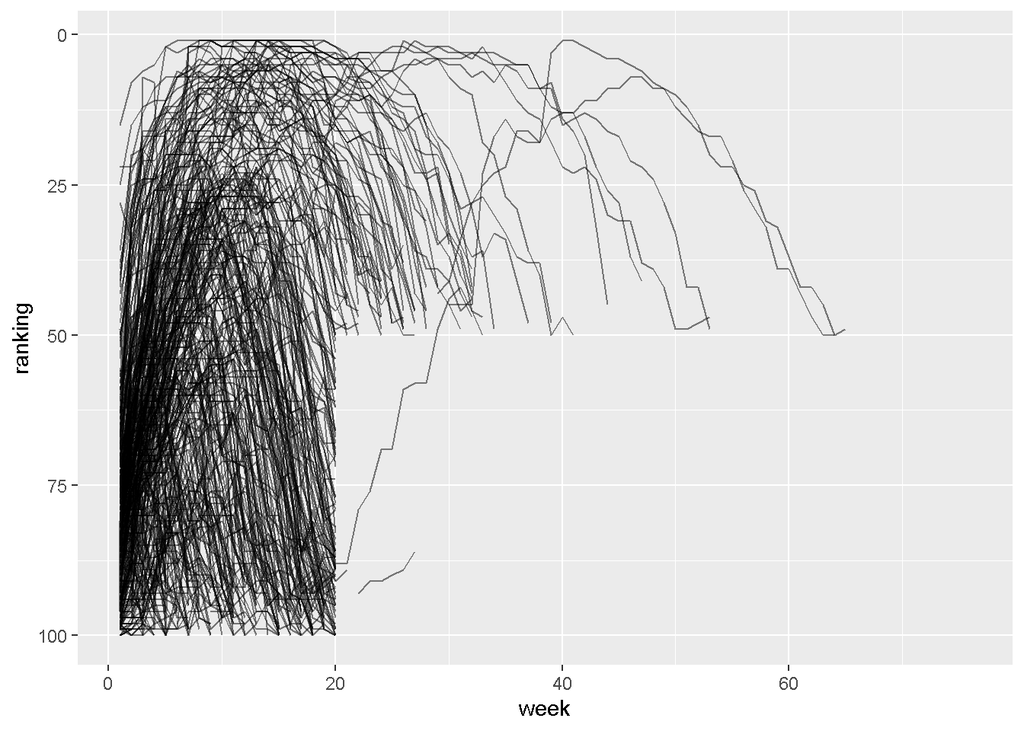

```r
billboard_l |>
  ggplot(aes(x = week, y = ranking, group = track)) +
  geom_line(alpha = .5) +
  scale_y_reverse()
```

### 7d) Make three more modifications to this plot.

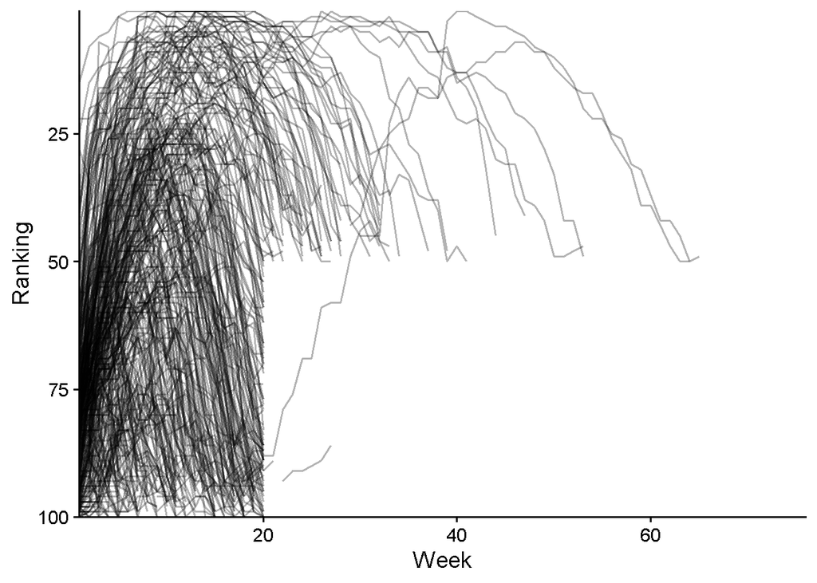

```r
billboard_l |>
  ggplot(aes(x = week, y = ranking, group = track)) +
  geom_line(alpha = .3) +
  scale_y_reverse() +
  coord_cartesian(expand = F) +
  labs(x = "Week", y = "Ranking") +
  theme_classic(base_size = 14)
```

### 7e) Describe what you see in this plot (1–2 sentences).